# logistics_auditor

The Schema Builder

```python
import pandas as pd
import numpy as np
import matplotlib.pyplot as plt
from IPython.display import display

orders = pd.read_csv("dataset/olist_orders_dataset.csv")
reviews = pd.read_csv("dataset/olist_order_reviews_dataset.csv")
customers = pd.read_csv("dataset/olist_customers_dataset.csv")
products = pd.read_csv("dataset/olist_products_dataset.csv")
translation = pd.read_csv("dataset/product_category_name_translation.csv")

pd.set_option("display.max_rows", None)
pd.set_option("display.max_columns", None)
pd.set_option("display.width", None)
pd.set_option("display.max_colwidth", None)

print("Orders")
display(orders.head())

print("-------- shape --------")
print(orders.shape)

print("-------- columns --------")
print(orders.columns.tolist())

print("-------- info --------")
orders.info()

print("-------- nullity --------")
display(orders.isna().sum().to_frame("null_count"))

print("\nReviews")
display(reviews.head())

print("-------- shape --------")
print(reviews.shape)

print("-------- columns --------")
print(reviews.columns.tolist())

print("-------- info --------")
reviews.info()

print("-------- nullity --------")
display(reviews.isna().sum().to_frame("null_count"))

display(customers.head())

print("-------- shape --------")
print(customers.shape)

print("-------- columns --------")
print(customers.columns.tolist())

print("-------- info --------")
customers.info()

print("-------- nullity --------")
display(customers.isna().sum().to_frame("null_count"))

print("\nProducts")
display(products.head())

print("-------- shape --------")
print(products.shape)

print("-------- columns --------")
print(products.columns.tolist())

print("-------- info --------")
products.info()

print("-------- nullity --------")
display(products.isna().sum().to_frame("null_count"))

print("\nTranslation")
display(translation.head())

print("-------- shape --------")
print(translation.shape)

print("-------- columns --------")
print(translation.columns.tolist())

print("-------- info --------")
translation.info()

print("-------- nullity --------")
display(translation.isna().sum().to_frame("null_count"))
```

```
Orders
```

|  | order_id | customer_id | order_status | order_purchase_timestamp | order_approved_at | order_delivered_carrier_date | order_delivered_customer_date | order_estimated_delivery_date |
| --- | --- | --- | --- | --- | --- | --- | --- | --- |
| 0 | e481f51cbdc54678b7cc49136f2d6af7 | 9ef432eb6251297304e76186b10a928d | delivered | 2017-10-02 10:56:33 | 2017-10-02 11:07:15 | 2017-10-04 19:55:00 | 2017-10-10 21:25:13 | 2017-10-18 00:00:00 |
| 1 | 53cdb2fc8bc7dce0b6741e2150273451 | b0830fb4747a6c6d20dea0b8c802d7ef | delivered | 2018-07-24 20:41:37 | 2018-07-26 03:24:27 | 2018-07-26 14:31:00 | 2018-08-07 15:27:45 | 2018-08-13 00:00:00 |
| 2 | 47770eb9100c2d0c44946d9cf07ec65d | 41ce2a54c0b03bf3443c3d931a367089 | delivered | 2018-08-08 08:38:49 | 2018-08-08 08:55:23 | 2018-08-08 13:50:00 | 2018-08-17 18:06:29 | 2018-09-04 00:00:00 |
| 3 | 949d5b44dbf5de918fe9c16f97b45f8a | f88197465ea7920adcdbec7375364d82 | delivered | 2017-11-18 19:28:06 | 2017-11-18 19:45:59 | 2017-11-22 13:39:59 | 2017-12-02 00:28:42 | 2017-12-15 00:00:00 |
| 4 | ad21c59c0840e6cb83a9ceb5573f8159 | 8ab97904e6daea8866dbdbc4fb7aad2c | delivered | 2018-02-13 21:18:39 | 2018-02-13 22:20:29 | 2018-02-14 19:46:34 | 2018-02-16 18:17:02 | 2018-02-26 00:00:00 |

```
-------- shape --------
(99441, 8)
-------- columns --------
['order_id', 'customer_id', 'order_status', 'order_purchase_timestamp', 'order_approved_at', 'order_delivered_carrier_date', 'order_delivered_customer_date', 'order_estimated_delivery_date']
-------- info --------
<class 'pandas.DataFrame'>
RangeIndex: 99441 entries, 0 to 99440
Data columns (total 8 columns):
 #   Column                         Non-Null Count  Dtype
---  ------                         --------------  -----
 0   order_id                       99441 non-null  str
 1   customer_id                    99441 non-null  str
 2   order_status                   99441 non-null  str
 3   order_purchase_timestamp       99441 non-null  str
 4   order_approved_at              99281 non-null  str
 5   order_delivered_carrier_date   97658 non-null  str
 6   order_delivered_customer_date  96476 non-null  str
 7   order_estimated_delivery_date  99441 non-null  str
dtypes: str(8)
memory usage: 6.1 MB
-------- nullity --------
```

|  | null_count |
| --- | --- |
| order_id | 0 |
| customer_id | 0 |
| order_status | 0 |
| order_purchase_timestamp | 0 |
| order_approved_at | 160 |
| order_delivered_carrier_date | 1783 |
| order_delivered_customer_date | 2965 |
| order_estimated_delivery_date | 0 |

```
Reviews
```

|  | review_id | order_id | review_score | review_comment_title | review_comment_message | review_creation_date | review_answer_timestamp |
| --- | --- | --- | --- | --- | --- | --- | --- |
| 0 | 7bc2406110b926393aa56f80a40eba40 | 73fc7af87114b39712e6da79b0a377eb | 4 | NaN | NaN | 2018-01-18 00:00:00 | 2018-01-18 21:46:59 |
| 1 | 80e641a11e56f04c1ad469d5645fdfde | a548910a1c6147796b98fdf73dbeba33 | 5 | NaN | NaN | 2018-03-10 00:00:00 | 2018-03-11 03:05:13 |
| 2 | 228ce5500dc1d8e020d8d1322874b6f0 | f9e4b658b201a9f2ecdecbb34bed034b | 5 | NaN | NaN | 2018-02-17 00:00:00 | 2018-02-18 14:36:24 |
| 3 | e64fb393e7b32834bb789ff8bb30750e | 658677c97b385a9be170737859d3511b | 5 | NaN | Recebi bem antes do prazo estipulado. | 2017-04-21 00:00:00 | 2017-04-21 22:02:06 |
| 4 | f7c4243c7fe1938f181bec41a392bdeb | 8e6bfb81e283fa7e4f11123a3fb894f1 | 5 | NaN | Parabéns lojas lannister adorei comprar pela Internet seguro e prático Parabéns a todos feliz Páscoa | 2018-03-01 00:00:00 | 2018-03-02 10:26:53 |

```
-------- shape --------
(99224, 7)
-------- columns --------
['review_id', 'order_id', 'review_score', 'review_comment_title', 'review_comment_message', 'review_creation_date', 'review_answer_timestamp']
-------- info --------
<class 'pandas.DataFrame'>
RangeIndex: 99224 entries, 0 to 99223
Data columns (total 7 columns):
 #   Column                   Non-Null Count  Dtype
---  ------                   --------------  -----
 0   review_id                99224 non-null  str
 1   order_id                 99224 non-null  str
 2   review_score             99224 non-null  int64
 3   review_comment_title     11568 non-null  str
 4   review_comment_message   40977 non-null  str
 5   review_creation_date     99224 non-null  str
 6   review_answer_timestamp  99224 non-null  str
dtypes: int64(1), str(6)
memory usage: 5.3 MB
-------- nullity --------
```

|  | null_count |
| --- | --- |
| review_id | 0 |
| order_id | 0 |
| review_score | 0 |
| review_comment_title | 87656 |
| review_comment_message | 58247 |
| review_creation_date | 0 |
| review_answer_timestamp | 0 |

|  | customer_id | customer_unique_id | customer_zip_code_prefix | customer_city | customer_state |
| --- | --- | --- | --- | --- | --- |
| 0 | 06b8999e2fba1a1fbc88172c00ba8bc7 | 861eff4711a542e4b93843c6dd7febb0 | 14409 | franca | SP |
| 1 | 18955e83d337fd6b2def6b18a428ac77 | 290c77bc529b7ac935b93aa66c333dc3 | 9790 | sao bernardo do campo | SP |
| 2 | 4e7b3e00288586ebd08712fdd0374a03 | 060e732b5b29e8181a18229c7b0b2b5e | 1151 | sao paulo | SP |
| 3 | b2b6027bc5c5109e529d4dc6358b12c3 | 259dac757896d24d7702b9acbbff3f3c | 8775 | mogi das cruzes | SP |
| 4 | 4f2d8ab171c80ec8364f7c12e35b23ad | 345ecd01c38d18a9036ed96c73b8d066 | 13056 | campinas | SP |

```
-------- shape --------
(99441, 5)
-------- columns --------
['customer_id', 'customer_unique_id', 'customer_zip_code_prefix', 'customer_city', 'customer_state']
-------- info --------
<class 'pandas.DataFrame'>
RangeIndex: 99441 entries, 0 to 99440
Data columns (total 5 columns):
 #   Column                    Non-Null Count  Dtype
---  ------                    --------------  -----
 0   customer_id               99441 non-null  str
 1   customer_unique_id        99441 non-null  str
 2   customer_zip_code_prefix  99441 non-null  int64
 3   customer_city             99441 non-null  str
 4   customer_state            99441 non-null  str
dtypes: int64(1), str(4)
memory usage: 3.8 MB
-------- nullity --------
```

|  | null_count |
| --- | --- |
| customer_id | 0 |
| customer_unique_id | 0 |
| customer_zip_code_prefix | 0 |
| customer_city | 0 |
| customer_state | 0 |

```
Products
```

|  | product_id | product_category_name | product_name_lenght | product_description_lenght | product_photos_qty | product_weight_g | product_length_cm | product_height_cm | product_width_cm |
| --- | --- | --- | --- | --- | --- | --- | --- | --- | --- |
| 0 | 1e9e8ef04dbcff4541ed26657ea517e5 | perfumaria | 40.0 | 287.0 | 1.0 | 225.0 | 16.0 | 10.0 | 14.0 |
| 1 | 3aa071139cb16b67ca9e5dea641aaa2f | artes | 44.0 | 276.0 | 1.0 | 1000.0 | 30.0 | 18.0 | 20.0 |
| 2 | 96bd76ec8810374ed1b65e291975717f | esporte_lazer | 46.0 | 250.0 | 1.0 | 154.0 | 18.0 | 9.0 | 15.0 |
| 3 | cef67bcfe19066a932b7673e239eb23d | bebes | 27.0 | 261.0 | 1.0 | 371.0 | 26.0 | 4.0 | 26.0 |
| 4 | 9dc1a7de274444849c219cff195d0b71 | utilidades_domesticas | 37.0 | 402.0 | 4.0 | 625.0 | 20.0 | 17.0 | 13.0 |

```
-------- shape --------
(32951, 9)
-------- columns --------
['product_id', 'product_category_name', 'product_name_lenght', 'product_description_lenght', 'product_photos_qty', 'product_weight_g', 'product_length_cm', 'product_height_cm', 'product_width_cm']
-------- info --------
<class 'pandas.DataFrame'>
RangeIndex: 32951 entries, 0 to 32950
Data columns (total 9 columns):
 #   Column                      Non-Null Count  Dtype
---  ------                      --------------  -----
 0   product_id                  32951 non-null  str
 1   product_category_name       32341 non-null  str
 2   product_name_lenght         32341 non-null  float64
 3   product_description_lenght  32341 non-null  float64
 4   product_photos_qty          32341 non-null  float64
 5   product_weight_g            32949 non-null  float64
 6   product_length_cm           32949 non-null  float64
 7   product_height_cm           32949 non-null  float64
 8   product_width_cm            32949 non-null  float64
dtypes: float64(7), str(2)
memory usage: 2.3 MB
-------- nullity --------
```

|  | null_count |
| --- | --- |
| product_id | 0 |
| product_category_name | 610 |
| product_name_lenght | 610 |
| product_description_lenght | 610 |
| product_photos_qty | 610 |
| product_weight_g | 2 |
| product_length_cm | 2 |
| product_height_cm | 2 |
| product_width_cm | 2 |

```
Translation
```

|  | product_category_name | product_category_name_english |
| --- | --- | --- |
| 0 | beleza_saude | health_beauty |
| 1 | informatica_acessorios | computers_accessories |
| 2 | automotivo | auto |
| 3 | cama_mesa_banho | bed_bath_table |
| 4 | moveis_decoracao | furniture_decor |

```
-------- shape --------
(71, 2)
-------- columns --------
['product_category_name', 'product_category_name_english']
-------- info --------
<class 'pandas.DataFrame'>
RangeIndex: 71 entries, 0 to 70
Data columns (total 2 columns):
 #   Column                         Non-Null Count  Dtype
---  ------                         --------------  -----
 0   product_category_name          71 non-null     str
 1   product_category_name_english  71 non-null     str
dtypes: str(2)
memory usage: 1.2 KB
-------- nullity --------
```

|  | null_count |
| --- | --- |
| product_category_name | 0 |
| product_category_name_english | 0 |

```python
#converting date columns
date_cols = [
    "order_purchase_timestamp",
    "order_approved_at",
    "order_delivered_carrier_date",
    "order_delivered_customer_date",
    "order_estimated_delivery_date"
]

for col in date_cols:
    orders[col] = pd.to_datetime(orders[col], errors="coerce")

orders.info()
```

```
<class 'pandas.DataFrame'>
RangeIndex: 99441 entries, 0 to 99440
Data columns (total 8 columns):
 #   Column                         Non-Null Count  Dtype
---  ------                         --------------  -----
 0   order_id                       99441 non-null  str
 1   customer_id                    99441 non-null  str
 2   order_status                   99441 non-null  str
 3   order_purchase_timestamp       99441 non-null  datetime64[us]
 4   order_approved_at              99281 non-null  datetime64[us]
 5   order_delivered_carrier_date   97658 non-null  datetime64[us]
 6   order_delivered_customer_date  96476 non-null  datetime64[us]
 7   order_estimated_delivery_date  99441 non-null  datetime64[us]
dtypes: datetime64[us](5), str(3)
memory usage: 6.1 MB
```

```python
#checking for duplicates in keys
reviews["order_id"].duplicated().sum(), customers["customer_id"].duplicated().sum()
```

```
(np.int64(551), np.int64(0))
```

```python
dup_reviews = reviews[reviews["order_id"].duplicated(keep=False)].sort_values("order_id")
dup_reviews.head(20)
```

|  | review_id | order_id | review_score | review_comment_title | review_comment_message | review_creation_date | review_answer_timestamp |
| --- | --- | --- | --- | --- | --- | --- | --- |
| 25612 | 89a02c45c340aeeb1354a24e7d4b2c1e | 0035246a40f520710769010f752e7507 | 5 | NaN | NaN | 2017-08-29 00:00:00 | 2017-08-30 01:59:12 |
| 22423 | 2a74b0559eb58fc1ff842ecc999594cb | 0035246a40f520710769010f752e7507 | 5 | NaN | Estou acostumada a comprar produtos pelo baratheon. Super confiável, transparência, qualidade e agilidade. Super recomendo. | 2017-08-25 00:00:00 | 2017-08-29 21:45:57 |
| 22779 | ab30810c29da5da8045216f0f62652a2 | 013056cfe49763c6f66bda03396c5ee3 | 5 | NaN | NaN | 2018-02-22 00:00:00 | 2018-02-23 12:12:30 |
| 68633 | 73413b847f63e02bc752b364f6d05ee9 | 013056cfe49763c6f66bda03396c5ee3 | 4 | NaN | NaN | 2018-03-04 00:00:00 | 2018-03-05 17:02:00 |
| 854 | 830636803620cdf8b6ffaf1b2f6e92b2 | 0176a6846bcb3b0d3aa3116a9a768597 | 5 | NaN | NaN | 2017-12-30 00:00:00 | 2018-01-02 10:54:06 |
| 83224 | d8e8c42271c8fb67b9dad95d98c8ff80 | 0176a6846bcb3b0d3aa3116a9a768597 | 5 | NaN | NaN | 2017-12-30 00:00:00 | 2018-01-02 10:54:47 |
| 17582 | 017f0e1ea6386de662cbeba299c59ad1 | 02355020fd0a40a0d56df9f6ff060413 | 1 | NaN | ja reclamei varias vezes e ate hoje não sei onde foi parar o produto que comprei. quero cancelar esta compra e quero meu dinheiro de volta. | 2018-03-29 00:00:00 | 2018-03-30 03:16:19 |
| 89888 | 0c8e7347f1cdd2aede37371543e3d163 | 02355020fd0a40a0d56df9f6ff060413 | 3 | NaN | UM DOS PRODUTOS (ENTREGA02) COMPRADOS NESTE PEDIDO NAO RECEBI AINDA E OUTRO (ENTREGA01) RECEBI EMAIL QUE ESTA COM DIFICULDADES NA ENTREGA E NÃO TIVE MAIS NOTICIAS | 2018-03-21 00:00:00 | 2018-03-22 01:32:08 |
| 55137 | 61fe4e7d1ae801bbe169eb67b86c6eda | 029863af4b968de1e5d6a82782e662f5 | 4 | NaN | NaN | 2017-07-19 00:00:00 | 2017-07-20 12:06:11 |
| 37911 | 04d945e95c788a3aa1ffbee42105637b | 029863af4b968de1e5d6a82782e662f5 | 5 | NaN | NaN | 2017-07-14 00:00:00 | 2017-07-17 13:58:06 |
| 35812 | fa493ead9b093fb0fa6f7d4905b0ef3b | 02e0b68852217f5715fb9cc885829454 | 4 | NaN | Gostei e entregou rapidinho | 2017-12-01 00:00:00 | 2017-12-03 21:57:31 |
| 17847 | 2eab0b2e6f5bded4d9b0b2afcfdf4534 | 02e0b68852217f5715fb9cc885829454 | 4 | NaN | Gostei chegou rapidinho | 2017-12-03 00:00:00 | 2017-12-03 21:56:37 |
| 35052 | 38821b5c496b678cf91acc34892805ad | 02e723e8edb4a123d414f56cc9c4665e | 5 | NaN | NaN | 2017-09-03 00:00:00 | 2017-09-05 12:12:51 |
| 42500 | 39b4603793c1c7f5f36d809b4a218664 | 02e723e8edb4a123d414f56cc9c4665e | 5 | NaN | Otimo | 2017-09-01 00:00:00 | 2017-09-02 12:13:03 |
| 49625 | 5e1ee2e924a1dd10d80b99555383c0a7 | 03515a836bb855b03f7df9dee520a8fc | 5 | NaN | NaN | 2018-01-31 00:00:00 | 2018-02-01 01:26:24 |
| 38386 | 1dee9d450a2b8533d2085cef898ca4a2 | 03515a836bb855b03f7df9dee520a8fc | 5 | NaN | NaN | 2018-02-06 00:00:00 | 2018-02-06 17:19:21 |
| 51527 | f4bb9d6dd4fb6dcc2298f0e7b17b8e1e | 03c939fd7fd3b38f8485a0f95798f1f6 | 4 | NaN | NaN | 2018-03-29 00:00:00 | 2018-03-30 00:29:09 |
| 8273 | b04ed893318da5b863e878cd3d0511df | 03c939fd7fd3b38f8485a0f95798f1f6 | 3 | NaN | Um ponto negativo que achei foi a cobrança de 3 taxas de entregas, sendo que comprei os 3 produtos iguais numa só compra.\r\nE mesmo comprando os produtos juntos, chegaram separados. | 2018-03-20 00:00:00 | 2018-03-21 02:28:23 |
| 69438 | 405eb2ea45e1dbe2662541ae5b47e2aa | 03c939fd7fd3b38f8485a0f95798f1f6 | 3 | NaN | Seria ótimo se tivesem entregue os 3 (três) pedidos de uma única vez. | 2018-03-06 00:00:00 | 2018-03-06 19:50:32 |
| 92880 | 55bff212ccac64cbacab9dae14850dcd | 03eba6d9fef8f5b3e811d4b5a7cca9cd | 5 | NaN | NaN | 2018-03-06 00:00:00 | 2018-03-09 00:09:40 |

```python
#count number of each duplicate order id
dup_reviews["order_id"].value_counts().head(10)
```

```
order_id
03c939fd7fd3b38f8485a0f95798f1f6    3
8e17072ec97ce29f0e1f111e598b0c85    3
c88b1d1b157a9999ce368f218a407141    3
df56136b8031ecd28e200bb18e6ddb2e    3
0035246a40f520710769010f752e7507    2
013056cfe49763c6f66bda03396c5ee3    2
0176a6846bcb3b0d3aa3116a9a768597    2
02355020fd0a40a0d56df9f6ff060413    2
029863af4b968de1e5d6a82782e662f5    2
02e0b68852217f5715fb9cc885829454    2
Name: count, dtype: int64
```

```python
# converting review dates
review_date_cols = ["review_creation_date", "review_answer_timestamp"]

for col in review_date_cols:
    reviews[col] = pd.to_datetime(reviews[col], errors="coerce")

# keeping the latest review per order
cleaned_reviews = (
    reviews.sort_values("review_answer_timestamp")
           .drop_duplicates(subset="order_id", keep="last")
)

# confirm uniqueness
cleaned_reviews["order_id"].duplicated().sum()
```

```
np.int64(0)
```

```python
reviews.shape, cleaned_reviews.shape
```

```
((99224, 7), (98673, 7))
```

```python
#merging the tables
master = orders.merge(cleaned_reviews, on="order_id", how="left")
master = master.merge(customers, on="customer_id", how="left")

master.shape
```

```
(99441, 18)
```

```python
#check for duplicates once more
master["order_id"].duplicated().sum()
```

```
np.int64(0)
```

```python
master.head()
```

|  | order_id | customer_id | order_status | order_purchase_timestamp | order_approved_at | order_delivered_carrier_date | order_delivered_customer_date | order_estimated_delivery_date | review_id | review_score | review_comment_title | review_comment_message | review_creation_date | review_answer_timestamp | customer_unique_id | customer_zip_code_prefix | customer_city | customer_state |
| --- | --- | --- | --- | --- | --- | --- | --- | --- | --- | --- | --- | --- | --- | --- | --- | --- | --- | --- |
| 0 | e481f51cbdc54678b7cc49136f2d6af7 | 9ef432eb6251297304e76186b10a928d | delivered | 2017-10-02 10:56:33 | 2017-10-02 11:07:15 | 2017-10-04 19:55:00 | 2017-10-10 21:25:13 | 2017-10-18 | a54f0611adc9ed256b57ede6b6eb5114 | 4.0 | NaN | Não testei o produto ainda, mas ele veio correto e em boas condições. Apenas a caixa que veio bem amassada e danificada, o que ficará chato, pois se trata de um presente. | 2017-10-11 | 2017-10-12 03:43:48 | 7c396fd4830fd04220f754e42b4e5bff | 3149 | sao paulo | SP |
| 1 | 53cdb2fc8bc7dce0b6741e2150273451 | b0830fb4747a6c6d20dea0b8c802d7ef | delivered | 2018-07-24 20:41:37 | 2018-07-26 03:24:27 | 2018-07-26 14:31:00 | 2018-08-07 15:27:45 | 2018-08-13 | 8d5266042046a06655c8db133d120ba5 | 4.0 | Muito boa a loja | Muito bom o produto. | 2018-08-08 | 2018-08-08 18:37:50 | af07308b275d755c9edb36a90c618231 | 47813 | barreiras | BA |
| 2 | 47770eb9100c2d0c44946d9cf07ec65d | 41ce2a54c0b03bf3443c3d931a367089 | delivered | 2018-08-08 08:38:49 | 2018-08-08 08:55:23 | 2018-08-08 13:50:00 | 2018-08-17 18:06:29 | 2018-09-04 | e73b67b67587f7644d5bd1a52deb1b01 | 5.0 | NaN | NaN | 2018-08-18 | 2018-08-22 19:07:58 | 3a653a41f6f9fc3d2a113cf8398680e8 | 75265 | vianopolis | GO |
| 3 | 949d5b44dbf5de918fe9c16f97b45f8a | f88197465ea7920adcdbec7375364d82 | delivered | 2017-11-18 19:28:06 | 2017-11-18 19:45:59 | 2017-11-22 13:39:59 | 2017-12-02 00:28:42 | 2017-12-15 | 359d03e676b3c069f62cadba8dd3f6e8 | 5.0 | NaN | O produto foi exatamente o que eu esperava e estava descrito no site e chegou bem antes da data prevista. | 2017-12-03 | 2017-12-05 19:21:58 | 7c142cf63193a1473d2e66489a9ae977 | 59296 | sao goncalo do amarante | RN |
| 4 | ad21c59c0840e6cb83a9ceb5573f8159 | 8ab97904e6daea8866dbdbc4fb7aad2c | delivered | 2018-02-13 21:18:39 | 2018-02-13 22:20:29 | 2018-02-14 19:46:34 | 2018-02-16 18:17:02 | 2018-02-26 | e50934924e227544ba8246aeb3770dd4 | 5.0 | NaN | NaN | 2018-02-17 | 2018-02-18 13:02:51 | 72632f0f9dd73dfee390c9b22eb56dd6 | 9195 | santo andre | SP |

The "Real" Delay Calculator

```python
# use only the date part because estimate time only 00:00:00
master["delivered_date"] = master["order_delivered_customer_date"].dt.normalize()
master["estimated_date"] = master["order_estimated_delivery_date"].dt.normalize()

# day difference
master["Days_Difference"] = (
    master["estimated_date"] - master["delivered_date"]
).dt.days

master[["order_id", "order_status", "estimated_date", "delivered_date", "Days_Difference", "review_score"]].head()
```

|  | order_id | order_status | estimated_date | delivered_date | Days_Difference | review_score |
| --- | --- | --- | --- | --- | --- | --- |
| 0 | e481f51cbdc54678b7cc49136f2d6af7 | delivered | 2017-10-18 | 2017-10-10 | 8.0 | 4.0 |
| 1 | 53cdb2fc8bc7dce0b6741e2150273451 | delivered | 2018-08-13 | 2018-08-07 | 6.0 | 4.0 |
| 2 | 47770eb9100c2d0c44946d9cf07ec65d | delivered | 2018-09-04 | 2018-08-17 | 18.0 | 5.0 |
| 3 | 949d5b44dbf5de918fe9c16f97b45f8a | delivered | 2017-12-15 | 2017-12-02 | 13.0 | 5.0 |
| 4 | ad21c59c0840e6cb83a9ceb5573f8159 | delivered | 2018-02-26 | 2018-02-16 | 10.0 | 5.0 |

```python
# exclude canceled and unavailable orders
valid_orders = master[~master["order_status"].isin(["canceled", "unavailable"])].copy()

#classification
def classify_delivery(days_diff):
    if pd.isna(days_diff):
        return "Not Delivered"
    elif days_diff >= 0:
        return "On Time"
    elif days_diff >= -5:
        return "Late"
    else:
        return "Super Late"

valid_orders["delivery_status"] = valid_orders["Days_Difference"].apply(classify_delivery)

valid_orders["delivery_status"].value_counts()
```

```
delivery_status
On Time          89936
Super Late        3764
Late              2770
Not Delivered     1737
Name: count, dtype: int64
```

```python
valid_orders[["estimated_date","delivered_date","Days_Difference", "delivery_status"]].sample(10)
```

|  | estimated_date | delivered_date | Days_Difference | delivery_status |
| --- | --- | --- | --- | --- |
| 96603 | 2018-08-16 | 2018-08-16 | 0.0 | On Time |
| 78433 | 2018-05-14 | 2018-05-02 | 12.0 | On Time |
| 80816 | 2018-01-04 | 2017-12-12 | 23.0 | On Time |
| 1060 | 2018-03-02 | 2018-02-14 | 16.0 | On Time |
| 3149 | 2018-03-15 | 2018-03-19 | -4.0 | Late |
| 77099 | 2017-03-21 | 2017-02-21 | 28.0 | On Time |
| 4803 | 2016-11-30 | 2016-10-21 | 40.0 | On Time |
| 29905 | 2017-09-22 | 2017-09-14 | 8.0 | On Time |
| 40577 | 2018-05-24 | 2018-05-02 | 22.0 | On Time |
| 74542 | 2018-01-03 | 2017-12-19 | 15.0 | On Time |

The Geographic Heatmap

```python
#% of late orders per state

state_perf = valid_orders.groupby("customer_state").agg(
    total_orders=("order_id", "count"),
    late_orders=("delivery_status", lambda x: x.isin(["Late", "Super Late"]).sum())
).reset_index()

state_perf["late_percentage"] = (state_perf["late_orders"] / state_perf["total_orders"]) * 100

state_perf.sort_values("late_percentage", ascending=False).head(10)
```

|  | customer_state | total_orders | late_orders | late_percentage |
| --- | --- | --- | --- | --- |
| 1 | AL | 411 | 85 | 20.681265 |
| 9 | MA | 736 | 125 | 16.983696 |
| 24 | SE | 345 | 51 | 14.782609 |
| 16 | PI | 490 | 66 | 13.469388 |
| 5 | CE | 1323 | 176 | 13.303099 |
| 4 | BA | 3344 | 396 | 11.842105 |
| 18 | RJ | 12698 | 1495 | 11.773508 |
| 21 | RR | 45 | 5 | 11.111111 |
| 13 | PA | 969 | 106 | 10.939112 |
| 7 | ES | 2018 | 214 | 10.604559 |

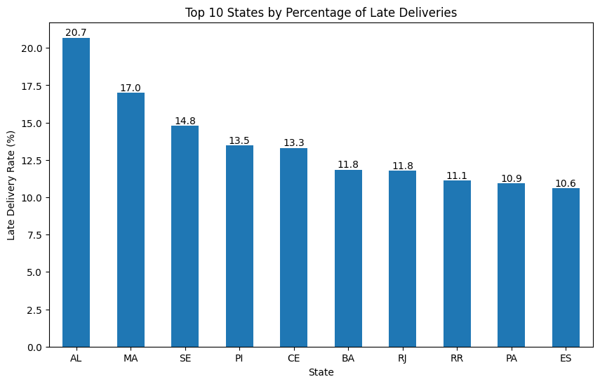

```python
#bar chart
top_late_states = state_perf.sort_values("late_percentage", ascending=False).head(10)

ax = top_late_states.plot(
    kind="bar",
    x="customer_state",
    y="late_percentage",
    figsize=(10, 6),
    title="Top 10 States by Percentage of Late Deliveries",
    legend=False
)

ax.set_xlabel("State")
ax.set_ylabel("Late Delivery Rate (%)")
ax.tick_params(axis="x", rotation=0)

for container in ax.containers:
    ax.bar_label(container, fmt="%.1f")
```

Sentiment Correlation

```python
#Sentiment Correlation

#grouping delivery statuses
review_by_status = valid_orders[
    valid_orders["delivery_status"] != "Not Delivered"
].groupby("delivery_status").agg(
    avg_review_score=("review_score", "mean"),
    count_orders=("order_id", "count")
).reset_index()

review_by_status
```

|  | delivery_status | avg_review_score | count_orders |
| --- | --- | --- | --- |
| 0 | Late | 2.988244 | 2770 |
| 1 | On Time | 4.290386 | 89936 |
| 2 | Super Late | 1.736540 | 3764 |

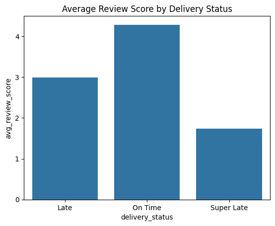

```python
import seaborn as sns
import matplotlib.pyplot as plt

sns.barplot(data=review_by_status, x="delivery_status", y="avg_review_score")
plt.title("Average Review Score by Delivery Status")
plt.show()
```

```python
#getting min and max day difference for bins
delivered = valid_orders[
    valid_orders["delivery_status"] != "Not Delivered"
]

delivered["Days_Difference"].min(), delivered["Days_Difference"].max()
```

```
(np.float64(-188.0), np.float64(147.0))
```

[figure not shown]

```python
# cap to get rid of outliers
delivered["Days_Difference_capped"] = delivered["Days_Difference"].clip(-30, 30)

delivered["delay_bin"] = pd.cut(
    delivered["Days_Difference_capped"],
    bins=[-30, -10, -5, 0, 3, 7, 30],
    labels=[
        "Very Late (>10 days)",
        "Late (5–10 days)",
        "Slightly Late (0–5 days)",
        "On Time",
        "Early (1–3 days)",
        "Very Early (>3 days)"
    ]
)

delay_review = delivered.groupby("delay_bin")["review_score"].mean().reset_index()

sns.barplot(data=delay_review, x="delay_bin", y="review_score")
plt.xticks(rotation=45)
plt.title("Review Score by Delay Range")
plt.show()
```

#### Insight

Customer satisfaction and delivery delays are clearly negatively correlated. The average review score is higher for orders that are delivered on time than for those that are delivered late, especially very late. This confirms that delays in logistics directly impact customer experience.

The "Translation" Challenge

```python
products = pd.read_csv("dataset/olist_products_dataset.csv")
translations = pd.read_csv("dataset/product_category_name_translation.csv")

display(products.head())
display(translations.head())
```

|  | product_id | product_category_name | product_name_lenght | product_description_lenght | product_photos_qty | product_weight_g | product_length_cm | product_height_cm | product_width_cm |
| --- | --- | --- | --- | --- | --- | --- | --- | --- | --- |
| 0 | 1e9e8ef04dbcff4541ed26657ea517e5 | perfumaria | 40.0 | 287.0 | 1.0 | 225.0 | 16.0 | 10.0 | 14.0 |
| 1 | 3aa071139cb16b67ca9e5dea641aaa2f | artes | 44.0 | 276.0 | 1.0 | 1000.0 | 30.0 | 18.0 | 20.0 |
| 2 | 96bd76ec8810374ed1b65e291975717f | esporte_lazer | 46.0 | 250.0 | 1.0 | 154.0 | 18.0 | 9.0 | 15.0 |
| 3 | cef67bcfe19066a932b7673e239eb23d | bebes | 27.0 | 261.0 | 1.0 | 371.0 | 26.0 | 4.0 | 26.0 |
| 4 | 9dc1a7de274444849c219cff195d0b71 | utilidades_domesticas | 37.0 | 402.0 | 4.0 | 625.0 | 20.0 | 17.0 | 13.0 |

|  | product_category_name | product_category_name_english |
| --- | --- | --- |
| 0 | beleza_saude | health_beauty |
| 1 | informatica_acessorios | computers_accessories |
| 2 | automotivo | auto |
| 3 | cama_mesa_banho | bed_bath_table |
| 4 | moveis_decoracao | furniture_decor |

```python
order_items = pd.read_csv("dataset/olist_order_items_dataset.csv")
display (order_items.head())
```

|  | order_id | order_item_id | product_id | seller_id | shipping_limit_date | price | freight_value |
| --- | --- | --- | --- | --- | --- | --- | --- |
| 0 | 00010242fe8c5a6d1ba2dd792cb16214 | 1 | 4244733e06e7ecb4970a6e2683c13e61 | 48436dade18ac8b2bce089ec2a041202 | 2017-09-19 09:45:35 | 58.90 | 13.29 |
| 1 | 00018f77f2f0320c557190d7a144bdd3 | 1 | e5f2d52b802189ee658865ca93d83a8f | dd7ddc04e1b6c2c614352b383efe2d36 | 2017-05-03 11:05:13 | 239.90 | 19.93 |
| 2 | 000229ec398224ef6ca0657da4fc703e | 1 | c777355d18b72b67abbeef9df44fd0fd | 5b51032eddd242adc84c38acab88f23d | 2018-01-18 14:48:30 | 199.00 | 17.87 |
| 3 | 00024acbcdf0a6daa1e931b038114c75 | 1 | 7634da152a4610f1595efa32f14722fc | 9d7a1d34a5052409006425275ba1c2b4 | 2018-08-15 10:10:18 | 12.99 | 12.79 |
| 4 | 00042b26cf59d7ce69dfabb4e55b4fd9 | 1 | ac6c3623068f30de03045865e4e10089 | df560393f3a51e74553ab94004ba5c87 | 2017-02-13 13:57:51 | 199.90 | 18.14 |

```python
#merging
master_with_products = master.merge(
    order_items[["order_id", "product_id"]],
    on="order_id",
    how="left"
).merge(
    products[["product_id", "product_category_name"]],
    on="product_id",
    how="left"
).merge(
    translations,
    on="product_category_name",
    how="left"
)

master_with_products.head()
```

|  | order_id | customer_id | order_status | order_purchase_timestamp | order_approved_at | order_delivered_carrier_date | order_delivered_customer_date | order_estimated_delivery_date | review_id | review_score | review_comment_title | review_comment_message | review_creation_date | review_answer_timestamp | customer_unique_id | customer_zip_code_prefix | customer_city | customer_state | delivered_date | estimated_date | Days_Difference | product_id | product_category_name | product_category_name_english |
| --- | --- | --- | --- | --- | --- | --- | --- | --- | --- | --- | --- | --- | --- | --- | --- | --- | --- | --- | --- | --- | --- | --- | --- | --- |
| 0 | e481f51cbdc54678b7cc49136f2d6af7 | 9ef432eb6251297304e76186b10a928d | delivered | 2017-10-02 10:56:33 | 2017-10-02 11:07:15 | 2017-10-04 19:55:00 | 2017-10-10 21:25:13 | 2017-10-18 | a54f0611adc9ed256b57ede6b6eb5114 | 4.0 | NaN | Não testei o produto ainda, mas ele veio correto e em boas condições. Apenas a caixa que veio bem amassada e danificada, o que ficará chato, pois se trata de um presente. | 2017-10-11 | 2017-10-12 03:43:48 | 7c396fd4830fd04220f754e42b4e5bff | 3149 | sao paulo | SP | 2017-10-10 | 2017-10-18 | 8.0 | 87285b34884572647811a353c7ac498a | utilidades_domesticas | housewares |
| 1 | 53cdb2fc8bc7dce0b6741e2150273451 | b0830fb4747a6c6d20dea0b8c802d7ef | delivered | 2018-07-24 20:41:37 | 2018-07-26 03:24:27 | 2018-07-26 14:31:00 | 2018-08-07 15:27:45 | 2018-08-13 | 8d5266042046a06655c8db133d120ba5 | 4.0 | Muito boa a loja | Muito bom o produto. | 2018-08-08 | 2018-08-08 18:37:50 | af07308b275d755c9edb36a90c618231 | 47813 | barreiras | BA | 2018-08-07 | 2018-08-13 | 6.0 | 595fac2a385ac33a80bd5114aec74eb8 | perfumaria | perfumery |
| 2 | 47770eb9100c2d0c44946d9cf07ec65d | 41ce2a54c0b03bf3443c3d931a367089 | delivered | 2018-08-08 08:38:49 | 2018-08-08 08:55:23 | 2018-08-08 13:50:00 | 2018-08-17 18:06:29 | 2018-09-04 | e73b67b67587f7644d5bd1a52deb1b01 | 5.0 | NaN | NaN | 2018-08-18 | 2018-08-22 19:07:58 | 3a653a41f6f9fc3d2a113cf8398680e8 | 75265 | vianopolis | GO | 2018-08-17 | 2018-09-04 | 18.0 | aa4383b373c6aca5d8797843e5594415 | automotivo | auto |
| 3 | 949d5b44dbf5de918fe9c16f97b45f8a | f88197465ea7920adcdbec7375364d82 | delivered | 2017-11-18 19:28:06 | 2017-11-18 19:45:59 | 2017-11-22 13:39:59 | 2017-12-02 00:28:42 | 2017-12-15 | 359d03e676b3c069f62cadba8dd3f6e8 | 5.0 | NaN | O produto foi exatamente o que eu esperava e estava descrito no site e chegou bem antes da data prevista. | 2017-12-03 | 2017-12-05 19:21:58 | 7c142cf63193a1473d2e66489a9ae977 | 59296 | sao goncalo do amarante | RN | 2017-12-02 | 2017-12-15 | 13.0 | d0b61bfb1de832b15ba9d266ca96e5b0 | pet_shop | pet_shop |
| 4 | ad21c59c0840e6cb83a9ceb5573f8159 | 8ab97904e6daea8866dbdbc4fb7aad2c | delivered | 2018-02-13 21:18:39 | 2018-02-13 22:20:29 | 2018-02-14 19:46:34 | 2018-02-16 18:17:02 | 2018-02-26 | e50934924e227544ba8246aeb3770dd4 | 5.0 | NaN | NaN | 2018-02-17 | 2018-02-18 13:02:51 | 72632f0f9dd73dfee390c9b22eb56dd6 | 9195 | santo andre | SP | 2018-02-16 | 2018-02-26 | 10.0 | 65266b2da20d04dbe00c5c2d3bb7859e | papelaria | stationery |

```python
#testing translation
master_with_products[[
    "product_category_name",
    "product_category_name_english"
]].drop_duplicates().head(20)
```

|  | product_category_name | product_category_name_english |
| --- | --- | --- |
| 0 | utilidades_domesticas | housewares |
| 1 | perfumaria | perfumery |
| 2 | automotivo | auto |
| 3 | pet_shop | pet_shop |
| 4 | papelaria | stationery |
| 6 | NaN | NaN |
| 8 | moveis_decoracao | furniture_decor |
| 9 | moveis_escritorio | office_furniture |
| 10 | ferramentas_jardim | garden_tools |
| 12 | informatica_acessorios | computers_accessories |
| 14 | cama_mesa_banho | bed_bath_table |
| 15 | brinquedos | toys |
| 17 | construcao_ferramentas_construcao | construction_tools_construction |
| 18 | telefonia | telephony |
| 21 | beleza_saude | health_beauty |
| 23 | eletronicos | electronics |
| 24 | bebes | baby |
| 26 | cool_stuff | cool_stuff |
| 30 | relogios_presentes | watches_gifts |
| 33 | climatizacao | air_conditioning |

```python
#translation data
data_translated = master_with_products[
    ~master_with_products["order_status"].isin(["canceled", "unavailable"])
].copy()

category_summary = data_translated.groupby("product_category_name_english").agg(
    total_orders=("order_id", "nunique"),
    avg_review_score=("review_score", "mean"),
    avg_days_difference=("Days_Difference", "mean")
).reset_index()

category_summary.head(30)
```

|  | product_category_name_english | total_orders | avg_review_score | avg_days_difference |
| --- | --- | --- | --- | --- |
| 0 | agro_industry_and_commerce | 182 | 4.000000 | 11.461165 |
| 1 | air_conditioning | 251 | 3.989655 | 14.169550 |
| 2 | art | 201 | 3.951456 | 12.776650 |
| 3 | arts_and_craftmanship | 23 | 4.125000 | 6.791667 |
| 4 | audio | 349 | 3.841226 | 10.149171 |
| 5 | auto | 3872 | 4.077385 | 11.437062 |
| 6 | baby | 2868 | 4.029490 | 11.646546 |
| 7 | bed_bath_table | 9399 | 3.901313 | 11.656167 |
| 8 | books_general_interest | 505 | 4.483395 | 12.152985 |
| 9 | books_imported | 53 | 4.400000 | 11.192982 |
| 10 | books_technical | 260 | 4.363636 | 11.307985 |
| 11 | cds_dvds_musicals | 12 | 4.642857 | 16.857143 |
| 12 | christmas_supplies | 127 | 4.041379 | 12.053333 |
| 13 | cine_photo | 65 | 4.194444 | 11.328571 |
| 14 | computers | 181 | 4.175000 | 11.577889 |
| 15 | computers_accessories | 6654 | 3.947402 | 12.419861 |
| 16 | consoles_games | 1054 | 4.051075 | 11.679522 |
| 17 | construction_tools_construction | 746 | 4.059653 | 11.621179 |
| 18 | construction_tools_lights | 243 | 4.071672 | 11.222591 |
| 19 | construction_tools_safety | 165 | 3.877660 | 12.387978 |
| 20 | cool_stuff | 3616 | 4.158218 | 12.492469 |
| 21 | costruction_tools_garden | 192 | 4.094017 | 13.543103 |
| 22 | costruction_tools_tools | 97 | 4.444444 | 12.203883 |
| 23 | diapers_and_hygiene | 26 | 3.315789 | 11.351351 |
| 24 | drinks | 296 | 4.040323 | 11.529086 |
| 25 | dvds_blu_ray | 57 | 4.180328 | 13.360656 |
| 26 | electronics | 2543 | 4.045322 | 11.139978 |
| 27 | fashio_female_clothing | 39 | 3.750000 | 11.288889 |
| 28 | fashion_bags_accessories | 1858 | 4.155412 | 13.335516 |
| 29 | fashion_childrens_clothes | 8 | 4.500000 | 15.714286 |

```python
#trying to get categories with volume
category_summary = category_summary[category_summary["total_orders"] >= 70]
```

```python
print("Worst Delivery timing")
display(category_summary.sort_values("avg_days_difference").head(10))
print("lowest reviews")
display(category_summary.sort_values("avg_review_score").head(10))
```

```
Worst Delivery timing
```

|  | product_category_name_english | total_orders | avg_review_score | avg_days_difference |
| --- | --- | --- | --- | --- |
| 47 | home_confort | 397 | 3.831019 | 9.811189 |
| 36 | food | 449 | 4.224696 | 9.867735 |
| 4 | audio | 349 | 3.841226 | 10.149171 |
| 33 | fashion_underwear_beach | 121 | 3.976923 | 10.929134 |
| 26 | electronics | 2543 | 4.045322 | 11.139978 |
| 18 | construction_tools_lights | 243 | 4.071672 | 11.222591 |
| 10 | books_technical | 260 | 4.363636 | 11.307985 |
| 68 | telephony | 4183 | 3.953737 | 11.382619 |
| 5 | auto | 3872 | 4.077385 | 11.437062 |
| 0 | agro_industry_and_commerce | 182 | 4.000000 | 11.461165 |

```
lowest reviews
```

|  | product_category_name_english | total_orders | avg_review_score | avg_days_difference |
| --- | --- | --- | --- | --- |
| 57 | office_furniture | 1272 | 3.492243 | 11.845923 |
| 30 | fashion_male_clothing | 111 | 3.661538 | 12.712000 |
| 34 | fixed_telephony | 214 | 3.713178 | 14.717647 |
| 47 | home_confort | 397 | 3.831019 | 9.811189 |
| 4 | audio | 349 | 3.841226 | 10.149171 |
| 19 | construction_tools_safety | 165 | 3.877660 | 12.387978 |
| 7 | bed_bath_table | 9399 | 3.901313 | 11.656167 |
| 40 | furniture_living_room | 420 | 3.909274 | 11.800000 |
| 39 | furniture_decor | 6425 | 3.918807 | 12.399510 |
| 48 | home_construction | 489 | 3.938230 | 11.557047 |

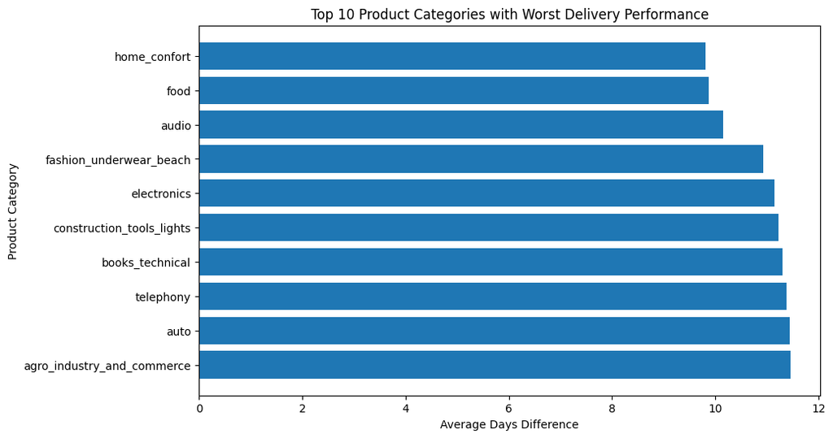

```python
top_delayed_categories = category_summary.sort_values("avg_days_difference").head(10)

plt.figure(figsize=(10,6))
plt.barh(top_delayed_categories["product_category_name_english"], top_delayed_categories["avg_days_difference"])
plt.xlabel("Average Days Difference")
plt.ylabel("Product Category")
plt.title("Top 10 Product Categories with Worst Delivery Performance")
plt.gca().invert_yaxis()
plt.show()
```

My Choice

```python
#My choice
order_items = pd.read_csv("dataset/olist_order_items_dataset.csv")

order_value = order_items.groupby("order_id").agg(
    total_price=("price", "sum"),
    total_freight=("freight_value", "sum")
).reset_index()

order_value.head()
```

|  | order_id | total_price | total_freight |
| --- | --- | --- | --- |
| 0 | 00010242fe8c5a6d1ba2dd792cb16214 | 58.90 | 13.29 |
| 1 | 00018f77f2f0320c557190d7a144bdd3 | 239.90 | 19.93 |
| 2 | 000229ec398224ef6ca0657da4fc703e | 199.00 | 17.87 |
| 3 | 00024acbcdf0a6daa1e931b038114c75 | 12.99 | 12.79 |
| 4 | 00042b26cf59d7ce69dfabb4e55b4fd9 | 199.90 | 18.14 |

```python
master_value = master.merge(order_value, on="order_id", how="left")
#adding a bad review field
master_value["bad_review"] = master_value["review_score"].apply(lambda x: 1 if x <= 2 else 0)
```

```python
state_bad_review = master_value.groupby("customer_state").agg(
    total_orders=("order_id", "nunique"),
    bad_review_orders=("bad_review", "sum"),
    total_revenue=("total_price", "sum"),
    bad_review_revenue=("total_price", lambda x: x[master_value.loc[x.index, "bad_review"] == 1].sum()),
    avg_review_score=("review_score", "mean")
).reset_index()

#bad review percentage
state_bad_review["bad_review_percentage"] = (
    state_bad_review["bad_review_orders"] / state_bad_review["total_orders"]
) * 100

state_bad_review.head()
```

|  | customer_state | total_orders | bad_review_orders | total_revenue | bad_review_revenue | avg_review_score | bad_review_percentage |
| --- | --- | --- | --- | --- | --- | --- | --- |
| 0 | AC | 81 | 13 | 15982.95 | 3079.19 | 4.049383 | 16.049383 |
| 1 | AL | 413 | 98 | 80314.81 | 17112.87 | 3.756098 | 23.728814 |
| 2 | AM | 148 | 21 | 22356.84 | 2873.22 | 4.205479 | 14.189189 |
| 3 | AP | 68 | 5 | 13474.30 | 406.37 | 4.194030 | 7.352941 |
| 4 | BA | 3380 | 631 | 511349.99 | 111171.34 | 3.861677 | 18.668639 |

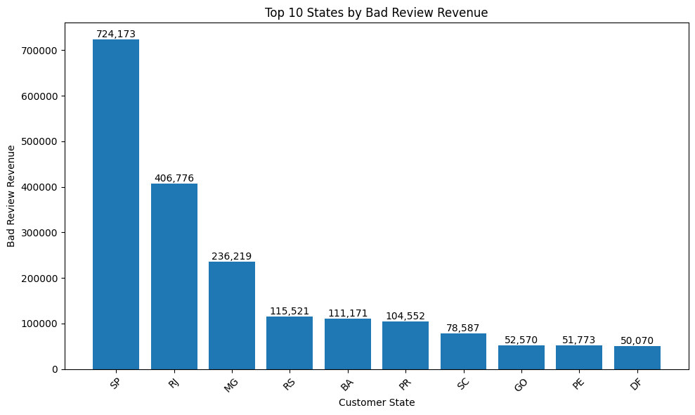

```python
# top 10 states by bad review revenue

top_10_bad_revenue = state_bad_review.sort_values(
    "bad_review_revenue", ascending=False
).head(10)

plt.figure(figsize=(10, 6))
bars = plt.bar(top_10_bad_revenue["customer_state"], top_10_bad_revenue["bad_review_revenue"])

plt.title("Top 10 States by Bad Review Revenue")
plt.xlabel("Customer State")
plt.ylabel("Bad Review Revenue")
plt.xticks(rotation=45)

for bar in bars:
    height = bar.get_height()
    plt.text(
        bar.get_x() + bar.get_width()/2,
        height,
        f"{height:,.0f}",
        ha="center",
        va="bottom"
    )

plt.tight_layout()
plt.show()
```

**Insight:** The chart shows that bad review revenue is heavily concentrated in a few key states, especially **SP**, which is far ahead of all others, followed by **RJ** and **MG**. This means that poor customer experiences in these high-revenue states may have a greater business impact than similar issues in lower-volume regions. For Veridi Logistics, these states should be treated as priority areas for operational improvement, since reducing service failures there could help protect customer trust and a significant share of revenue.

```python
#export to csv
master_value.to_csv("final_dataset.csv", index=False)
state_perf.to_csv("state_perf.csv", index=False)
review_by_status.to_csv("review_by_status.csv", index=False)
state_bad_review.to_csv("state_bad_review.csv", index=False)
delay_review.to_csv("delay_review.csv", index=False)
```